# Data Wrangling Project

## Storing Data

```python
# Store the clean dataframe in a csv file:
tweet_all.to_csv('twitter_archive_master.csv')
```

## Analyzing Data

### Dog Stage Popularity

#### Dog Stages: Ratings

```python
tweet_all.groupby('dog_stage')['dog_stage'].count()
```

```
dog_stage
doggo            55
doggo,floofer    1
doggo,pupper     8
doggo,puppo      1
floofer          6
pupper           194
puppo            22
Name: dog_stage, dtype: int64
```

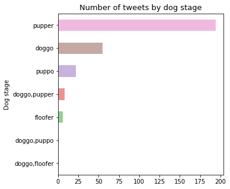

```python
fig, ax = plt.subplots(figsize=(5,5))
plt.title('Number of tweets by dog stage',fontsize=13)
plt.ylabel('Dog stage')
tweet_all['dog_stage'].value_counts(ascending=True).plot(kind="barh",alpha=0.5);
```

Pupper by far is the most common dog stage.

*Question:* Is pupper the most commonly posted dog stage because puppers are more likely to get higher ratings?

*Insight:* Multiple analyises below show that puppers, although the most common, actually have lower ratings and fewer likes.

*Note:* One might argue the sample size of some of the less common dog stages may skew their ratings. Regardless, all of the other stages, including the second most common doggo and third most common puppo stages, surpass the pupper stage in ratings, likes, and retweets.

**Mean**

```python
tweet_all.groupby('dog_stage')['rating_numerator'].mean().sort_values()
```

```
dog_stage
pupper           10.589021
doggo,pupper     10.750000
doggo,floofer    11.000000
doggo            11.854545
floofer          12.000000
puppo            12.000000
doggo,puppo      13.000000
Name: rating_numerator, dtype: float64
```

Puppers actually have the lowest average rating.

**Five Number Summary**

Let's look at the median in case those few outlier ratings are skewing the data.

```python
tweet_all.groupby('dog_stage')['rating_numerator'].describe().sort_values(by=['50%','mean'])
```

| dog_stage | count | mean | std | min | 25% | 50% | 75% | max |
| --- | --- | --- | --- | --- | --- | --- | --- | --- |
| pupper | 194.0 | 10.589021 | 1.708415 | 3.0 | 10.00 | 11.0 | 12.0 | 14.0 |
| doggo,floofer | 1.0 | 11.000000 | NaN | 11.0 | 11.00 | 11.0 | 11.0 | 11.0 |
| doggo,pupper | 8.0 | 10.750000 | 2.434866 | 5.0 | 10.75 | 12.0 | 12.0 | 12.0 |
| doggo | 55.0 | 11.854545 | 1.393346 | 8.0 | 11.00 | 12.0 | 13.0 | 14.0 |
| puppo | 22.0 | 12.000000 | 1.309307 | 9.0 | 11.25 | 12.0 | 13.0 | 14.0 |
| floofer | 6.0 | 12.000000 | 1.264911 | 10.0 | 11.25 | 12.5 | 13.0 | 13.0 |
| doggo,puppo | 1.0 | 13.000000 | NaN | 13.0 | 13.00 | 13.0 | 13.0 | 13.0 |

Puppers still tie for the lowest median rating numerator. Note that several categories have less than 10 posts (doggo-pupper, floofer, and doggo-puppo). Among the more common categories, doggo and puppo, puppers still underperform.

**Visual Plot**

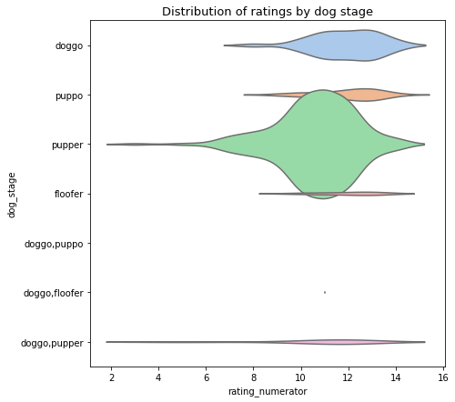

```python
fig, ax = plt.subplots(figsize=(7,7))
plt.title('Distribution of ratings by dog stage',fontsize=13)
ax = sb.violinplot(y='dog_stage',x='rating_numerator',data=tweet_all,palette='pastel',scale='count',inner=None,width=2.2)
```

Visually we can see the the majority of pupper ratings lag behind the other stages.

#### Dog Stages: Favorites and Rewteets

If we thought perhaps the users posting the puppers are just modest, giving their dogs lower ratings, we would be wrong. Judging by the median number of likes and retweets, a reflection of the opinion of the twitter audience, puppers still come in last.

```python
tweet_all.groupby('dog_stage')['favorite_count'].describe().sort_values(by=['50%','mean'])
```

| dog_stage | count | mean | std | min | 25% | 50% | 75% | max |
| --- | --- | --- | --- | --- | --- | --- | --- | --- |
| pupper | 194.0 | 6720.840206 | 10940.900581 | 660.0 | 2290.50 | 3035.0 | 6970.50 | 121299.0 |
| doggo,pupper | 8.0 | 13144.375000 | 15465.210358 | 4611.0 | 6837.75 | 8459.0 | 9436.00 | 51185.0 |
| doggo | 55.0 | 15430.963636 | 14598.756053 | 2462.0 | 7626.00 | 11185.0 | 18179.00 | 91689.0 |
| floofer | 6.0 | 13741.666667 | 11324.650099 | 2157.0 | 5526.00 | 11285.0 | 19590.25 | 31758.0 |
| puppo | 22.0 | 21667.727273 | 29594.481654 | 3102.0 | 6704.75 | 12830.5 | 18892.75 | 139582.0 |
| doggo,floofer | 1.0 | 16462.000000 | NaN | 16462.0 | 16462.00 | 16462.0 | 16462.00 | 16462.0 |
| doggo,puppo | 1.0 | 45966.000000 | NaN | 45966.0 | 45966.00 | 45966.0 | 45966.00 | 45966.0 |

```python
tweet_all.groupby('dog_stage')['retweet_count'].describe().sort_values(by=['50%','mean'])
```

| dog_stage | count | mean | std | min | 25% | 50% | 75% | max |
| --- | --- | --- | --- | --- | --- | --- | --- | --- |
| pupper | 194.0 | 2134.365979 | 3443.493436 | 96.0 | 647.50 | 1087.5 | 2142.25 | 35195.0 |
| doggo,pupper | 8.0 | 4105.875000 | 5558.185378 | 1188.0 | 1901.50 | 2336.0 | 2628.50 | 17773.0 |
| doggo | 55.0 | 4426.981818 | 5883.003955 | 675.0 | 1886.50 | 2699.0 | 4422.00 | 39825.0 |
| puppo | 22.0 | 6235.000000 | 10091.906602 | 658.0 | 1602.25 | 2928.0 | 5884.25 | 47352.0 |
| doggo,floofer | 1.0 | 3245.000000 | NaN | 3245.0 | 3245.00 | 3245.0 | 3245.00 | 3245.0 |
| floofer | 6.0 | 5031.333333 | 6203.797891 | 467.0 | 1564.75 | 3333.0 | 4438.25 | 17273.0 |
| doggo,puppo | 1.0 | 18157.000000 | NaN | 18157.0 | 18157.00 | 18157.0 | 18157.00 | 18157.0 |

### Dog Breeds

For this analysis, let's only examine breeds with 10 or more tweets, predicted at or above the median level of accuracy.

```python
median_accuracy = tweet_all['breed_accuracy'].median()
```

```python
breeds = tweet_all[tweet_all['breed_accuracy']>=median_accuracy]
```

```python
breed_sum = breeds.groupby('pred_breed')['favorite_count'].describe()
breeds_clean = breed_sum[breed_sum['count']>=10].sort_values('50%')
```

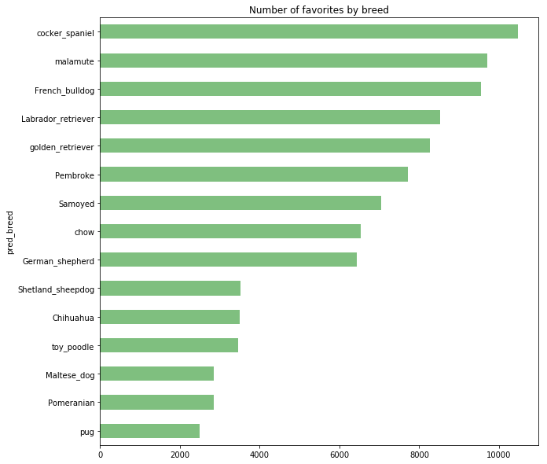

```python
fig, ax = plt.subplots(figsize=(10,10))
plt.title('Number of favorites by breed')
plt.ylabel('Breed')
breeds_clean['50%'].plot.barh(color='green',alpha=0.5);
```

The cocker spaniel is the clear winner, followed by the malamute. Here is your typical cocker spaniel on WeRateDogs:

```python
cocker_spaniel = breeds.query('pred_breed=="cocker_spaniel"')
```

```python
fav_spaniel_url = cocker_spaniel['jpg_url'][cocker_spaniel['favorite_count']==cocker_spaniel['favorite_count'].max()]
```

```python
fav_spaniel_count = cocker_spaniel['favorite_count'][cocker_spaniel['favorite_count']==cocker_spaniel['favorite_count'].max()]
fav_spaniel_txt = cocker_spaniel['text'][cocker_spaniel['favorite_count']==cocker_spaniel['favorite_count'].max()].iloc[0]
```

```python
with urllib.request.urlopen(fav_spaniel_url.iloc[0]) as url:
    f = io.BytesIO(url.read())

fav_spaniel_photo = Image.open(f)
```

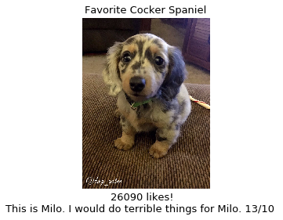

```python
fig, ax = plt.subplots()
plt.title('Favorite Cocker Spaniel', fontsize=13)
fig.text(.5,.07, '%d likes!' % fav_spaniel_count, ha='center',fontsize=13)
fig.text(.5,.02, '%s' % fav_spaniel_txt, ha='center',fontsize=13)
imshow(np.asarray(fav_spaniel_photo))
ax.set_axis_off()
# Reference: https://stackoverflow.com/questions/26649716/how-to-show-pil-image-in-ipython-notebook
# Removing gridlines/axes: https://matplotlib.org/gallery/images_contours_and_fields/image_transparency_blend.html#sphx-glr-gallery-images-contours-and-fields-image-transparency-blend-py
```

Who wouldn't do terrible things for Milo?

The breeds that tend to have the fewest favorites are pomeranians and pugs. Interestingly, the third most favorited breed is the French bulldog, which looks similar to the pug.

*Question:* Does it make a difference if you're a French bulldog or a pug?

*Insight:* Side-by-side photos and a news article suggest there may indeed be a meaningful difference between the breeds among the dog loving world.

```python
pug = breeds.query('pred_breed=="pug"')
fav_pug_txt = pug['text'][pug['favorite_count']==pug['favorite_count'].max()].iloc[0]
French_bulldog = breeds.query('pred_breed=="French_bulldog"')
```

```python
fav_bulldog_url = French_bulldog['jpg_url'][French_bulldog['favorite_count']==French_bulldog['favorite_count'].max()]
fav_pug_url = pug['jpg_url'][pug['favorite_count']==pug['favorite_count'].max()]
```

```python
fav_bulldog_txt = French_bulldog['text'][French_bulldog['favorite_count']==French_bulldog['favorite_count'].max()]
fav_pug_txt = pug['text'][pug['favorite_count']==pug['favorite_count'].max()].iloc[0]
```

```python
with urllib.request.urlopen(fav_bulldog_url.iloc[0]) as url:
    f = io.BytesIO(url.read())

fav_bulldog_photo = Image.open(f)
```

```python
with urllib.request.urlopen(fav_pug_url.iloc[0]) as url:
    f = io.BytesIO(url.read())

fav_pug_photo = Image.open(f)
```

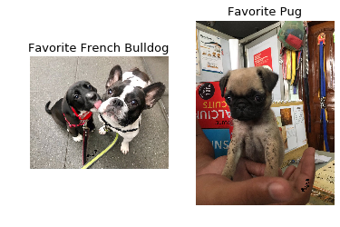

```python
ax = plt.subplot(1, 2, 1)
plt.title('Favorite French Bulldog',fontsize=13)
imshow(np.asarray(fav_bulldog_photo))
ax.set_axis_off()

ax = plt.subplot(1, 2, 2)
plt.title('Favorite Pug',fontsize=13)
imshow(np.asarray(fav_pug_photo))
ax.set_axis_off()
```

According to thehappypuppysite.com, there is a difference in popularity:

> [T]he French Bulldog currently ranks at number 6 in the USA and is New York’s most popular pup, taking second place in the UK. The Pug ranks at 32 in the USA but is more favoured in the UK at number 4.

Reference: https://thehappypuppysite.com/pug-vs-french-bulldog/

This real-world popularity ranking of 6 to 32 is almost the exact ratio of the twitter-world ranking in the graph above of 3 to 15.

## Good dogs, great dogs

For a sense of just how great and just how horrible these dogs can get, let's look at the dogs with the most and least number of likes.

*Question:* What is the range of likeability of these dogs?

*Insight:* The dogs on WeRateDogs range from good to great. Even the least liked dog could be considered pretty popular. There are some tweets with very low ratings, but a visual assessment of the text quickly clarifies that the ratings are due to the users or disatisfaction with the absence of dogs in a given photo.

### **The favorite dog**

```python
tweet_all.sort_values(by=['favorite_count'],ascending=False).head(2)
```

|  | tweet_id | in_reply_to_status_id | in_reply_to_user_id | timestamp | source | text | expanded_urls | rating_numerator | rating_denominator | name | dog_stage | jpg_url | pred_breed | breed_accuracy | retweet_count | favorite_count |
| --- | --- | --- | --- | --- | --- | --- | --- | --- | --- | --- | --- | --- | --- | --- | --- | --- |
| 295 | 822872901745569793 | NaN | NaN | 2017-01-21 18:26:02 +0000 | <a href="http://twitter.com/download/iphone" rel="nofollow">Twitter for iPhone</a> | Here's a super supportive puppo participating in the Toronto #WomensMarch today. 13/10 | https://twitter.com/dog_rates/status/822872901745569793/photo/1 | 13.0 | 10 | NaN | puppo | https://pbs.twimg.com/media/C2tugXLXgAArJO4.jpg | Lakeland_terrier | 0.196015 | 47352 | 139582 |
| 102 | 866450705531457537 | NaN | NaN | 2017-05-22 00:28:40 +0000 | <a href="http://twitter.com/download/iphone" rel="nofollow">Twitter for iPhone</a> | This is Jamesy. He gives a kiss to every other pupper he sees on his walk. 13/10 such passion, much tender | https://twitter.com/dog_rates/status/866450705531457537/photo/1,https://twitter.com/dog_rates/status/866450705531457537/photo/1 | 13.0 | 10 | Jamesy | pupper | https://pbs.twimg.com/media/DAZAUfBXcAAG_Nn.jpg | French_bulldog | 0.905334 | 35195 | 121299 |

```python
tweet_all[tweet_all['favorite_count']==tweet_all['favorite_count'].max()]
```

|  | tweet_id | in_reply_to_status_id | in_reply_to_user_id | timestamp | source | text | expanded_urls | rating_numerator | rating_denominator | name | dog_stage | jpg_url | pred_breed | breed_accuracy | retweet_count | favorite_count |
| --- | --- | --- | --- | --- | --- | --- | --- | --- | --- | --- | --- | --- | --- | --- | --- | --- |
| 295 | 822872901745569793 | NaN | NaN | 2017-01-21 18:26:02 +0000 | <a href="http://twitter.com/download/iphone" rel="nofollow">Twitter for iPhone</a> | Here's a super supportive puppo participating in the Toronto #WomensMarch today. 13/10 | https://twitter.com/dog_rates/status/822872901745569793/photo/1 | 13.0 | 10 | NaN | puppo | https://pbs.twimg.com/media/C2tugXLXgAArJO4.jpg | Lakeland_terrier | 0.196015 | 47352 | 139582 |

The most liked dog is a puppo, receiving 139,582 favorites. The predicted breed was inconclusive, with an accuracy rating of 20%. Interestingly, the most liked dog does not have the highest rating. Later we will explore the extent to which ratings, favorites, and retweets are correlated.

```python
best_URL = tweet_all['jpg_url'][tweet_all['favorite_count']==tweet_all['favorite_count'].max()]
with urllib.request.urlopen(best_URL.iloc[0]) as url:
    f = io.BytesIO(url.read())

best_photo = Image.open(f)
```

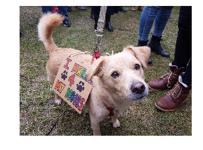

```python
fig, ax = plt.subplots()
imshow(np.asarray(best_photo))
ax.set_axis_off()
# Reference: https://stackoverflow.com/questions/26649716/how-to-show-pil-image-in-ipython-notebook
# Removing gridlines/axes: https://matplotlib.org/gallery/images_contours_and_fields/image_transparency_blend.html#sphx-glr-gallery-images-contours-and-fields-image-transparency-blend-py
```

### The least favorite dog

The "least liked" dog is still a good dog.

```python
least_URL = tweet_all['jpg_url'][tweet_all['favorite_count']==tweet_all['favorite_count'].min()]
with urllib.request.urlopen(least_URL.iloc[0]) as url:
    f = io.BytesIO(url.read())

least_photo = Image.open(f)
```

```python
least_txt = tweet_all['text'][tweet_all['favorite_count']==tweet_all['favorite_count'].min()].iloc[0]
least_fav = tweet_all['favorite_count'][tweet_all['favorite_count']==tweet_all['favorite_count'].min()].astype(int).iloc[0]
least_retweet = tweet_all['retweet_count'][tweet_all['favorite_count']==tweet_all['favorite_count'].min()].astype(int).iloc[0]
least_rating = tweet_all['rating_numerator'][tweet_all['favorite_count']==tweet_all['favorite_count'].min()].astype(int).iloc[0]
```

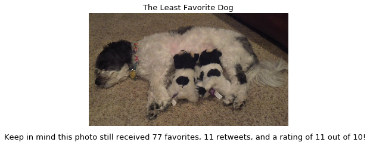

```python
fig, ax = plt.subplots()
plt.title('The Least Favorite Dog', fontsize=13)
fig.text(.5,.1, 'Keep in mind this photo still received %d favorites, %d retweets, and a rating of %d out of 10!'
      % (least_fav, least_retweet, least_rating), ha='center', fontsize=13)
imshow(np.asarray(least_photo))
ax.set_axis_off()
```

### The lowest rated dogs

Looking at the least liked did not yield any hideous pictures. Perhaps the posts rated lowest by the users will.

```python
lowest = tweet_all.query('rating_numerator==0')
```

```python
lowest[['text','rating_numerator','jpg_url','favorite_count']]
```

|  | text | rating_numerator | jpg_url | favorite_count |
| --- | --- | --- | --- | --- |
| 223 | When you're so blinded by your systematic plagiarism that you forget what day it is. 0/10 | 0.0 | NaN | 23459 |
| 708 | PUPDATE: can't see any. Even if I could, I couldn't reach them to pet. 0/10 much disappointment | 0.0 | NaN | 3011 |

Neiter of the lowest rated have photos of dogs recognizable by the neural network. Looking at the tweet texts, one was a user calling out plagiarism, and the other has no dog in the image. In both cases, it was users, not the dogs, that disappointed.

The plagiarized tweet is also a note of caution for using `favorite_count` to measure dog popularity. It was likely the message about plagiarizing that generated the likes.

### Users versus the audience

*Question:* Is there a correlation between how users rate their dogs and how the Twitter audience reacts?

*Insight:* After removing outliers in the `rating_numerator`, there appears to be a moderate positive relationship between `rating_numerator` on the one hand and `retweet_count` and `favorite_count` on the other. This suggests that there is some agreement as to what makes a good dog in the WeRateDogs universe, but that users also use this space for creative expression and fun, rather than just a strict assessment of dogs.

```python
tweet_all[['rating_numerator','retweet_count','favorite_count']].corr()
```

|  | rating_numerator | retweet_count | favorite_count |
| --- | --- | --- | --- |
| rating_numerator | 1.000000 | 0.028513 | 0.023664 |
| retweet_count | 0.028513 | 1.000000 | 0.929670 |
| favorite_count | 0.023664 | 0.929670 | 1.000000 |

Retweet and favorite counts are not surprisingly correlated (0.93). When including the full range of `rating_numerators`, there is no correlation between rating numerator and favorite or retweet count. This may be due to a couple factors:

- The ratings are given by the user posting the dog whereas the retweets and favorites reflect the audience's reaction.
- The rating system is subjective: Most ratings range from 10 to 14 - as high or higher than the denominator. There is not a single rubric defining these ratings, leaving it up to the interpretation of the user. There are also some very large ratings that users self-elected to assign their dogs.

Let's explore the dataset visually, focusing on the more standard ratings below 15:

```python
tweet_all_nonoutlier = tweet_all.query('rating_numerator<=14')
```

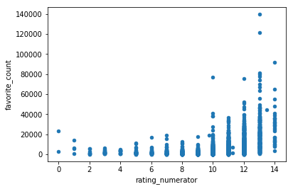

```python
tweet_all_nonoutlier.plot.scatter(x='rating_numerator',y='favorite_count');
```

```python
tweet_all_nonoutlier[['rating_numerator','retweet_count','favorite_count']].corr()
```

|  | rating_numerator | retweet_count | favorite_count |
| --- | --- | --- | --- |
| rating_numerator | 1.000000 | 0.333752 | 0.412984 |
| retweet_count | 0.333752 | 1.000000 | 0.929625 |
| favorite_count | 0.412984 | 0.929625 | 1.000000 |

If we remove the rating outliers, we see that the correlation between ratings and favorites increases from 0.02 to 0.41. The relationship also appears to be non-linear, with ratings below ten receiving fewer than 30,000 favorites, and favorites increasing as ratings rise from 10 to 14.

```python
tweet_all_standard = tweet_all_nonoutlier.query('rating_numerator>=10')
```

```python
tweet_all_standard[['rating_numerator','retweet_count','favorite_count']].corr()
```

|  | rating_numerator | retweet_count | favorite_count |
| --- | --- | --- | --- |
| rating_numerator | 1.000000 | 0.394802 | 0.494566 |
| retweet_count | 0.394802 | 1.000000 | 0.926549 |
| favorite_count | 0.494566 | 0.926549 | 1.000000 |

## Conclusions and Further Reserach

As we can see even the least favorited dog is not a bad dog at all, because

> they're good dogs Brent

> — WeRateDogs™ (@dog_rates) [September 12, 2016](https://twitter.com/dog_rates/status/775410014383026176?ref_src=twsrc%5Etfw)

*The impact of user popularity*

Further research should take into account users' followers. Controling for the number of followers a user has would help us account for the impact potential viewers has on likes and retweets. Another way to address the connection between user popularity and dog popularity would be to compare different dogs posted by the same user, or an A/A test by having different users post the same dog tweet.

*Are there* really *any bad dogs on WeRateDogs?*

The lowest rated dogs were due to either not containing dogs or to unethical behavior on the users part. The top dogs after all were marching for their moms. A deeper analysis of the texts of dogs rated below a 10 could reveal whether these are isolated cases or a trend in the community.

*Understanding the WeRateDogs community*

As we all know, they're all good dogs. To rise among the ranks, however, dogs may need to go beyond just looking cute and display some inner virtues. Looking at the numer one tweet, for example, reveals dogs that were committed enough to go on a march with their moms. An A/B test could be conducted by posting the same dog photo with different tweet content. Can the same dog improve its likes by getting off the counts and doing getting involved in a good cause?